# EMA_Microarray_Analysis

Tzu L. Phang

April 9, 2015

## Experimental Design

Read in descriptive data file and run summary statistics to examine the distribution of the data prior to importing CEL files

```r
options(width=500)
## Load EMA and oligo libraries
library(EMA)
library(oligo)

## Read in descriptive data file
PBHI.file.info = read.table(file = "./data/PHBI cel annotation BIO6660 v2.txt", header = T, sep = "\t")
## print(PBHI.file.info)
knitr::kable(PBHI.file.info)
```

| PHBI.cel.file | PHBI.number | Clinical.Category | Age | Race | Sex | Scan.Date | Batch |
| --- | --- | --- | --- | --- | --- | --- | --- |
| PHBI_001.cel | PHBI_001 | IPAH | 62 | White | Female | 10/1/09 | 1 |
| PHBI_002.cel | PHBI_002 | IPAH | 49 | White | Female | 10/1/09 | 1 |
| PHBI_003.cel | PHBI_003 | IPAH | 64 | White | Male | 10/1/09 | 1 |
| PHBI_019.cel | PHBI_019 | Failed Donor | 60 | White | Male | 10/1/09 | 1 |
| PHBI_027.cel | PHBI_027 | Failed Donor | 49 | White | Male | 10/1/09 | 1 |
| PHBI_042.cel | PHBI_042 | IPAH | 44 | White | Female | 10/1/10 | 2 |
| PHBI_044.cel | PHBI_044 | IPAH | 40 | White | Female | 10/1/10 | 2 |
| PHBI_053.cel | PHBI_053 | Failed Donor | 25 | White | Male | 10/1/10 | 2 |
| PHBI_059.cel | PHBI_059 | Failed Donor | 55 | White | Male | 10/1/10 | 2 |
| PHBI_062.cel | PHBI_062 | IPAH | 45 | White | Male | 10/1/10 | 2 |
| PHBI_066.cel | PHBI_066 | Failed Donor | 19 | White | Male | 10/1/10 | 2 |
| PHBI_067.cel | PHBI_067 | Failed Donor | 62 | White | Male | 10/1/11 | 3 |
| PHBI_068.cel | PHBI_068 | Failed Donor | 21 | White | Female | 10/1/11 | 3 |
| PHBI_069.cel | PHBI_069 | Failed Donor | 28 | White | Female | 10/1/11 | 3 |
| PHBI_073.cel | PHBI_073 | IPAH | 71 | White | Female | 10/1/11 | 3 |
| PHBI_075.cel | PHBI_075 | IPAH | 56 | White | Male | 10/1/11 | 3 |
| PHBI_078.cel | PHBI_078 | IPAH | 61 | White | Male | 10/1/11 | 3 |

We will use the “Clinical.Category” column to define the 2 comparing groups

```r
## Extract groups: IPAH and Failed Donor
PBHI.type.cl = as.character(PBHI.file.info$Clinical.Category)
PBHI.type.cl
```

```
##  [1] "IPAH"         "IPAH"         "IPAH"         "Failed Donor"
##  [5] "Failed Donor" "IPAH"         "IPAH"         "Failed Donor"
##  [9] "Failed Donor" "IPAH"         "Failed Donor" "Failed Donor"
## [13] "Failed Donor" "Failed Donor" "IPAH"         "IPAH"
## [17] "IPAH"
```

We suspect there might be batch-effect. We will use the “Batch” column to extract potential batch-effect information

```r
PBHI.batch.cl = PBHI.file.info$Batch
PBHI.batch.cl
```

```
##  [1] 1 1 1 1 1 2 2 2 2 2 2 3 3 3 3 3 3
```

What is the average age for the 2 groups of patients

```r
## Run basic summary statistics
tapply(PBHI.file.info$Age, PBHI.file.info$Clinical.Category, mean)
```

```
## Failed Donor         IPAH
##     39.87500     54.66667
```

What is the gender distribution

```r
tapply(PBHI.file.info$Sex, PBHI.file.info$Clinical.Category, summary)
```

```
## $`Failed Donor`
## Female   Male
##      2      6
##
## $IPAH
## Female   Male
##      5      4
```

### Visualize Age Distribution by Group

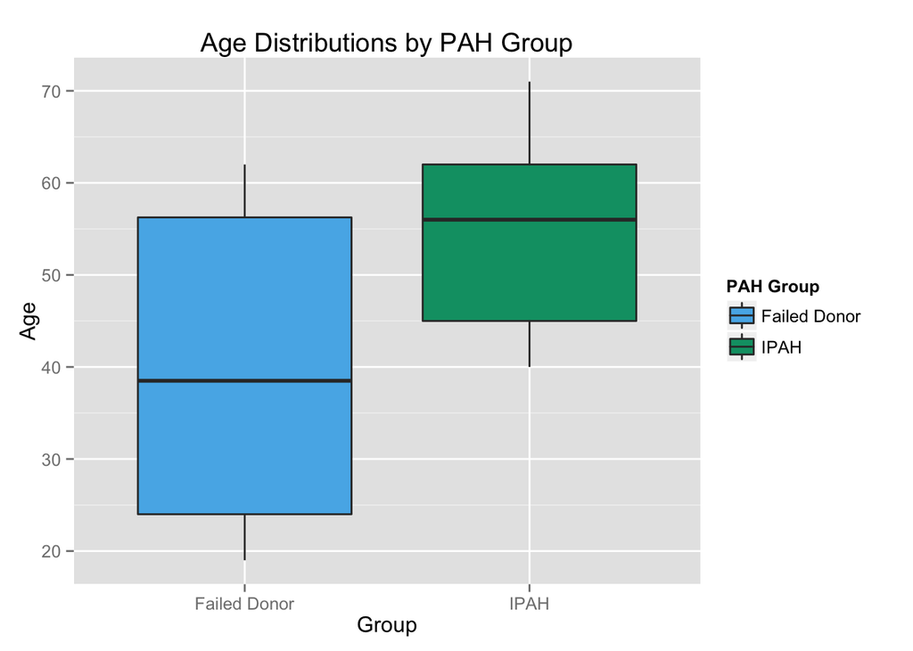

```r
library(ggplot2)

plot = ggplot(PBHI.file.info, aes(factor(PBHI.file.info$Clinical.Category),
    PBHI.file.info$Age)) + geom_boxplot(aes(fill = factor(PBHI.file.info$Clinical.Category))) +
    labs(title = "Age Distributions by PAH Group") + xlab("Group") + ylab("Age")
plot + scale_fill_manual("PAH Group", values = c("#56B4E9", "#009E73"))
```

## Preprocessing and Quality Assessemnt

### Import CEL files

Import CEL files, read in data, and normalize data using the RMA function

```r
## Import CEL files
PBHI.CEL = PBHI.file.info$PBHI.CEL
PBHI.CEL = list.celfiles('./data')
PBHI.CEL = paste('./data/', PBHI.CEL, sep = '')

## Read CEL files to directory
PHBI.data = read.celfiles(PBHI.CEL, verbose = F)
```

```
## Reading in : ./data/PHBI_001.CEL
## Reading in : ./data/PHBI_002.CEL
## Reading in : ./data/PHBI_003.CEL
## Reading in : ./data/PHBI_019.CEL
## Reading in : ./data/PHBI_027.CEL
## Reading in : ./data/PHBI_042.CEL
## Reading in : ./data/PHBI_044.CEL
## Reading in : ./data/PHBI_053.CEL
## Reading in : ./data/PHBI_059.CEL
## Reading in : ./data/PHBI_062.CEL
## Reading in : ./data/PHBI_066.CEL
## Reading in : ./data/PHBI_067.CEL
## Reading in : ./data/PHBI_068.CEL
## Reading in : ./data/PHBI_069.CEL
## Reading in : ./data/PHBI_073.CEL
## Reading in : ./data/PHBI_075.CEL
## Reading in : ./data/PHBI_078.CEL
```

```r
## Normalize the data
PHBI.norm = rma(PHBI.data)
```

```
## Background correcting
## Normalizing
## Calculating Expression
```

### Visual Inspection: Before and After Data Normalization

Create boxplots of log-intensity distribution to visualize data pre and post normalization

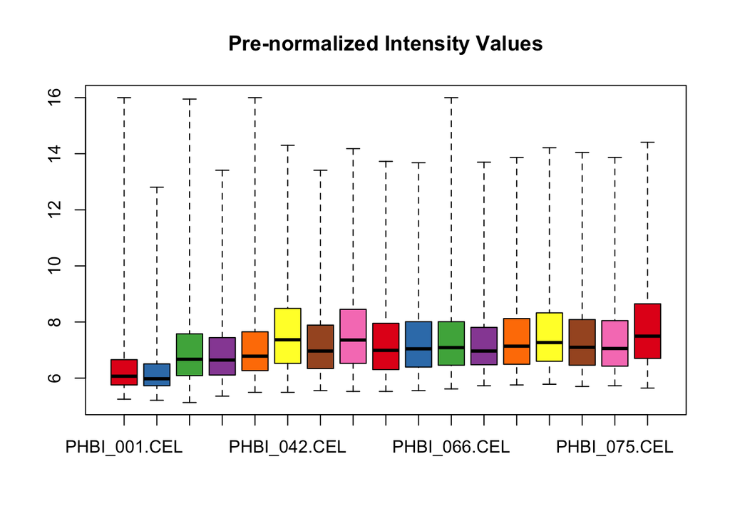

```r
## Load color libraries
library(RColorBrewer)

## Set color palette
color.palette = brewer.pal(8, "Set1")


## Pre-normalized intensity values boxplot
boxplot(PHBI.data, col = color.palette, main = "Pre-normalized Intensity Values")
```

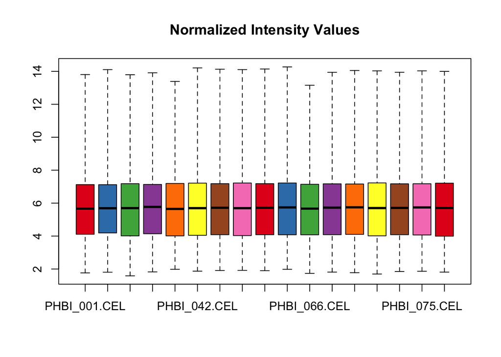

```r
## Normalized intensity values boxplot
boxplot(PHBI.norm, col = color.palette, main = "Normalized Intensity Values")
```

Create density plots of log-intensity distribution to visualize data pre and post normalizatio

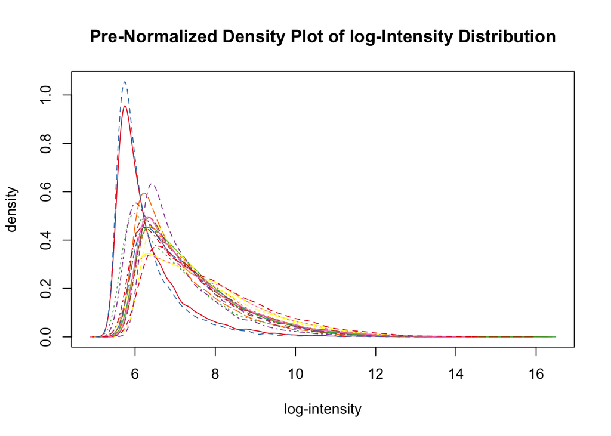

```r
## Pre-normalized density plot of log-intensity distribution
hist(PHBI.data, col = color.palette, main = "Pre-Normalized Density Plot of log-Intensity Distribution")
```

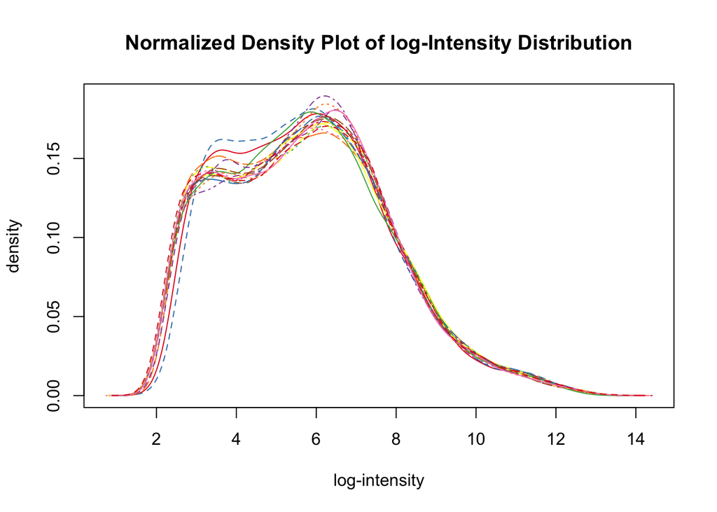

```r
## Normalized density plot of log-intensity distribution
hist(PHBI.norm, col = color.palette, main = "Normalized Density Plot of log-Intensity Distribution")
```

### Filtering Process

Extract normalized expression values and perform filtering to discard probesets below a specified threshold

```r
## Extract expression values after normalization, verify dimensions
PHBI.exprs = exprs(PHBI.norm)
dim(PHBI.exprs)
```

```
## [1] 33297    17
```

```r
## Filter and discard probesets with a maximum log2 expression value below 4,
## p=0.01
PUBHI.f = expFilter(PHBI.exprs, threshold = 4)
```

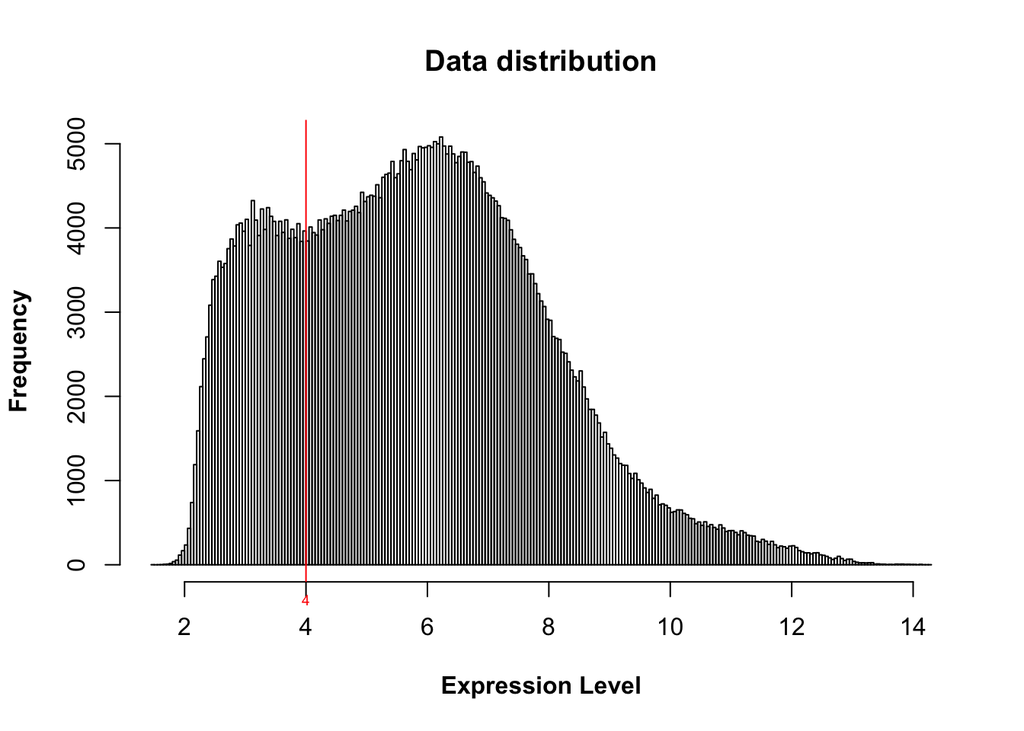

```
## Keep probes with at least 1 sample(s) with an expression level higher than 4
```

```r
## View data ditribution after filtering; remove threshold line
PUBHI.A = expFilter(PUBHI.f, threshold = F)
```

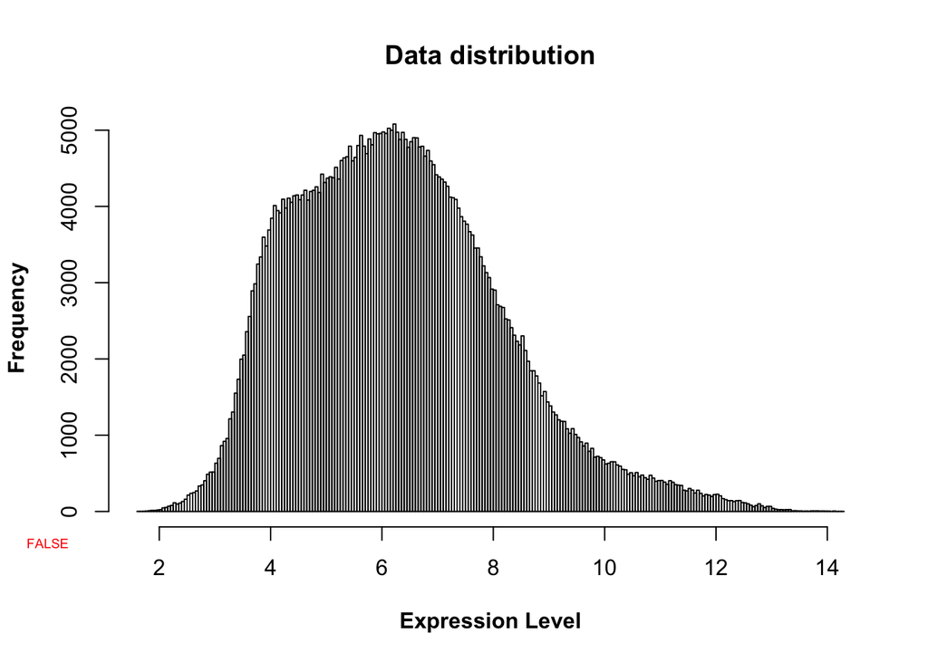

```
## Keep probes with at least 1 sample(s) with an expression level higher than FALSE
```

### Hierarchical Clustering

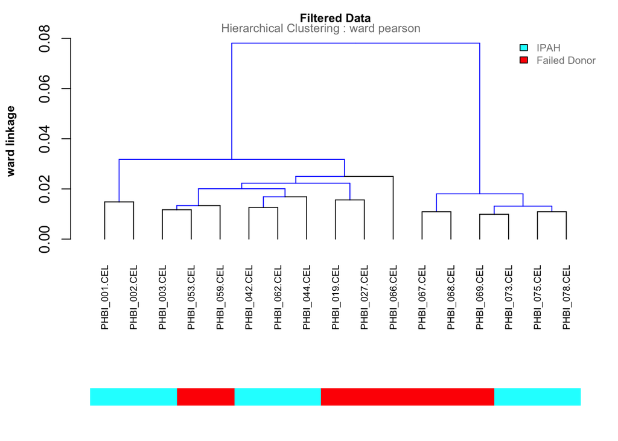

```r
PUBHI.sample = clustering(data = PUBHI.f, metric = "pearson", method = "ward")

## Visualize data pre and post filtering
clustering.plot(tree = PUBHI.sample, lab = PBHI.type.cl, title = "Filtered Data")
```

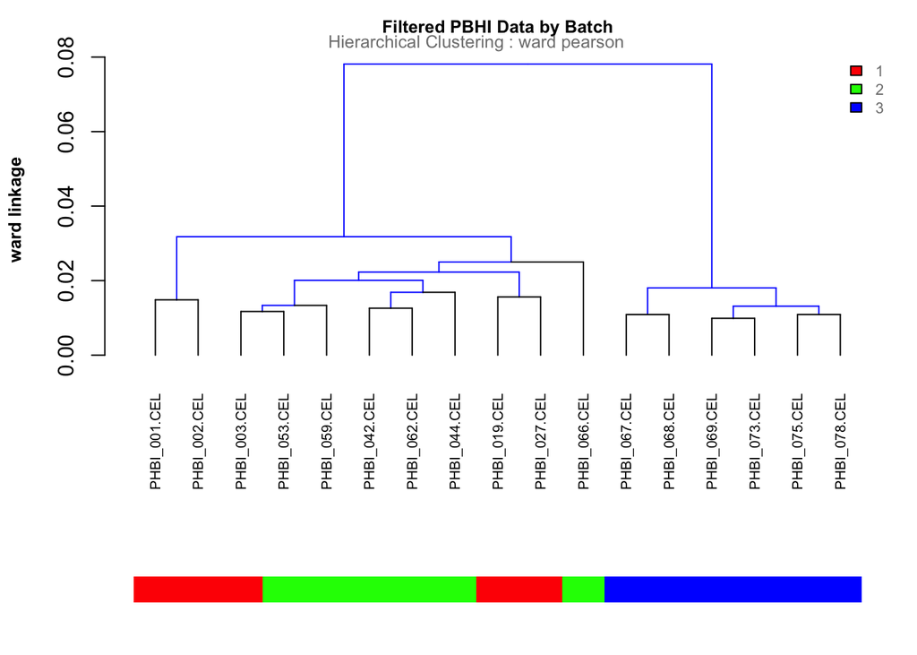

```r
clustering.plot(tree = PUBHI.sample, lab = PBHI.batch.cl, title = "Filtered PBHI Data by Batch")
```

### Principal Component Analysis

Run Principle Component Analysis (PCA) on the normalized and filtered data

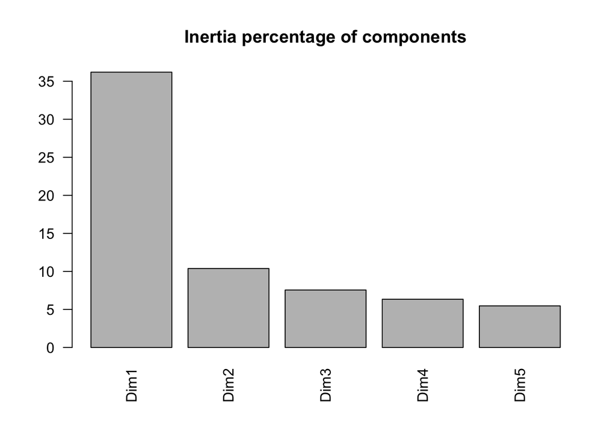

```r
## Segment variation into different components
acp = runPCA(t(PUBHI.f), scale = FALSE, lab.sample = PBHI.type.cl, plotSample = FALSE,
    plotInertia = FALSE)
plotInertia(acp)
```

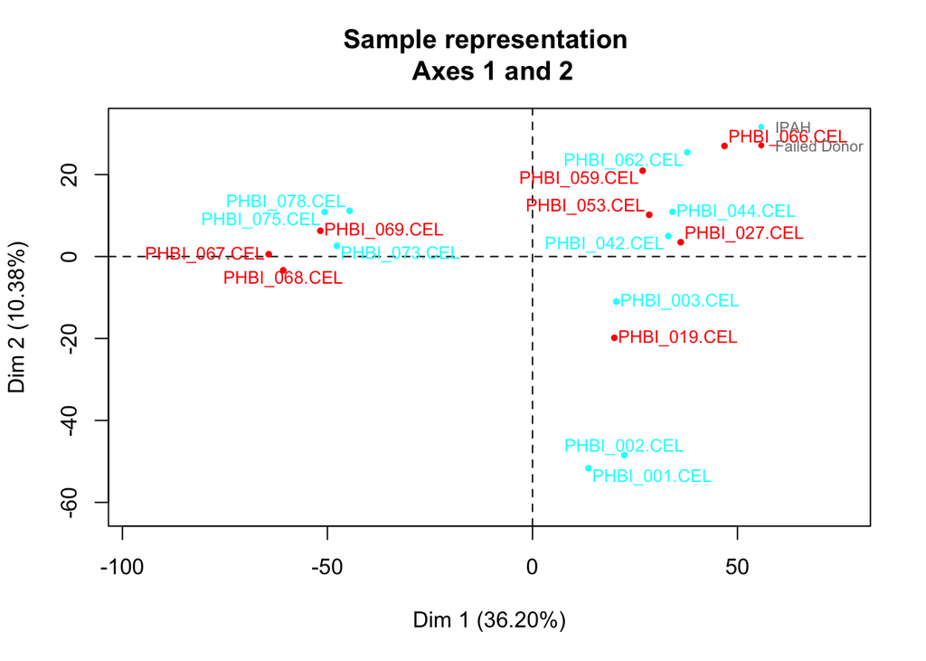

```r
## View pre-batch correction individual maps (axes 1 and 2) to look at the
## variation between groups and batches
plotSample(acp, axes = c(1, 2), lab = PBHI.type.cl)
```

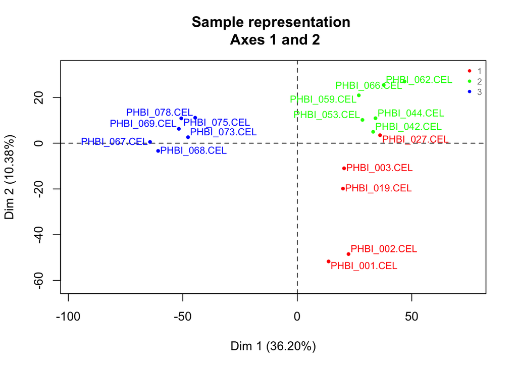

```r
plotSample(acp, axes = c(1, 2), lab = as.character(PBHI.batch.cl))
```

```r
## Create pdf report of PCA with selected plots
acp = runPCA(t(PUBHI.f), scale = FALSE, pdfname = "PCA.pdf", lab.sample = PBHI.type.cl)
```

### Batch Correction

Perform batch correction on the normalized data and re-run PCA to show post-batch correction improvements

```r
# Load sva library
library(sva)

## Create experimental design object and perform batch correction
mod = model.matrix(~as.factor(PBHI.type.cl))
combat_edata = ComBat(dat = PUBHI.f, batch = PBHI.batch.cl, mod = mod, numCovs = NULL,
    par.prior = TRUE, prior.plots = FALSE)
```

```
## Found 3 batches
## Found 1  categorical covariate(s)
## Standardizing Data across genes
## Fitting L/S model and finding priors
## Finding parametric adjustments
## Adjusting the Data
```

Run PCA and Hierarchical Clustering again after batch adjustment

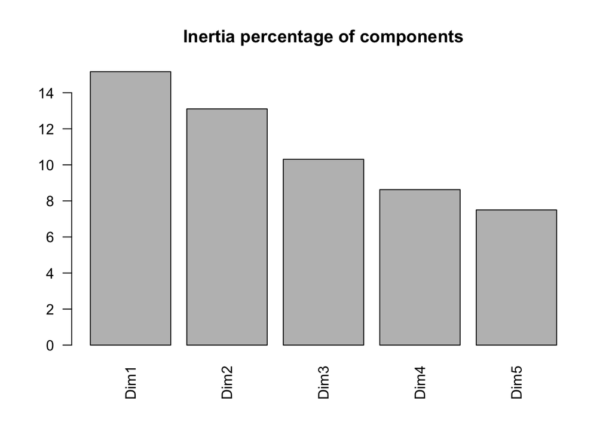

```r
## Run PCA after batch correction
acp = runPCA(t(combat_edata), scale = FALSE, lab.sample = PBHI.type.cl, plotSample = FALSE, plotInertia = FALSE)
plotInertia(acp)
```

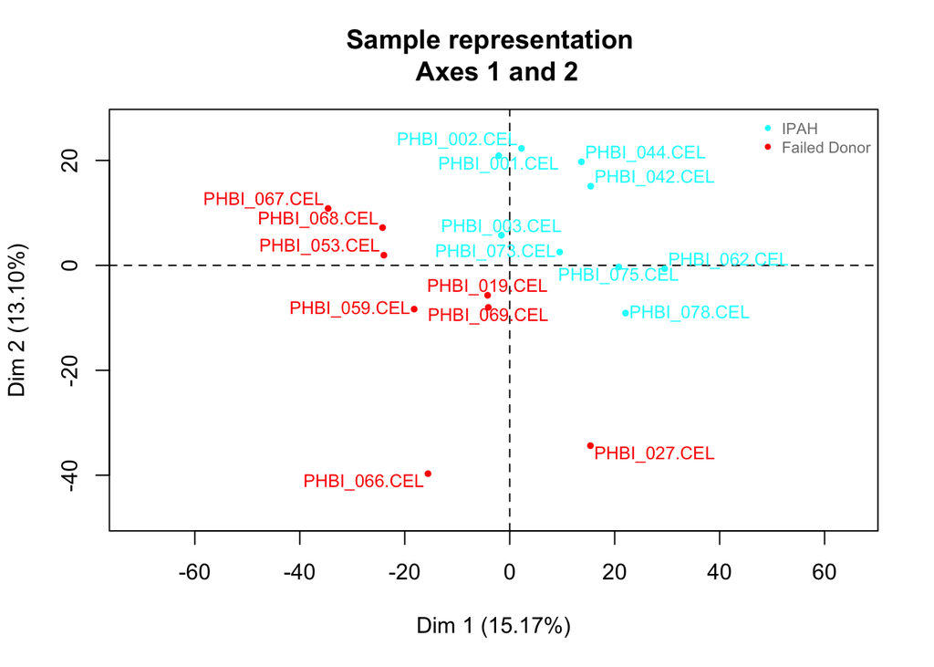

```r
## View post-batch correction individual maps (axes 1 and 2) to look at the
## variation between groups and batches
plotSample(acp, axes = c(1, 2), lab = PBHI.type.cl)
```

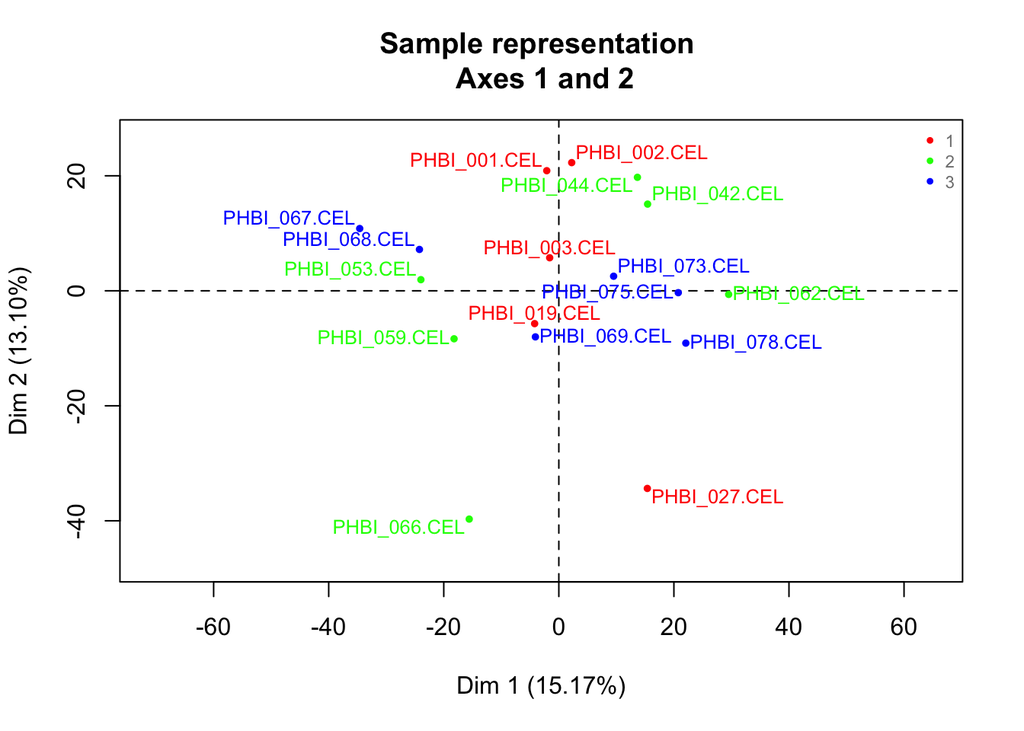

```r
plotSample(acp, axes = c(1, 2), lab = PBHI.batch.cl)
```

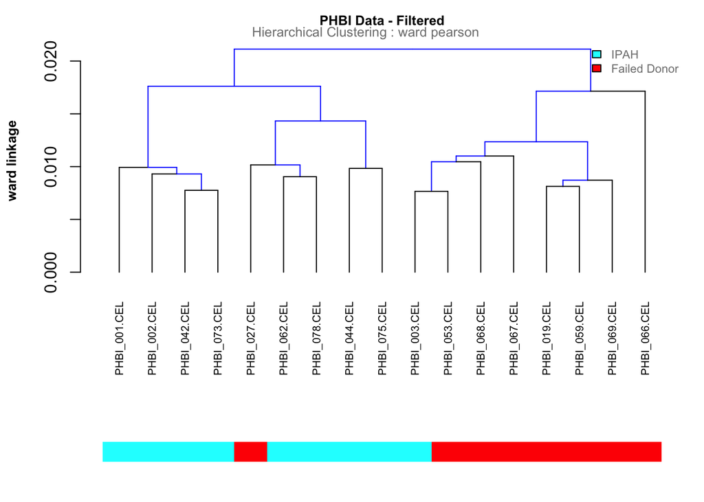

```r
## Sample Hierarchical Clustering (post-batch adjustment)
PUBHI.sample2 = clustering(data = combat_edata, metric = "pearson", method = "ward")
clustering.plot(tree = PUBHI.sample2, lab = PBHI.type.cl, title = "PHBI Data - Filtered")
```

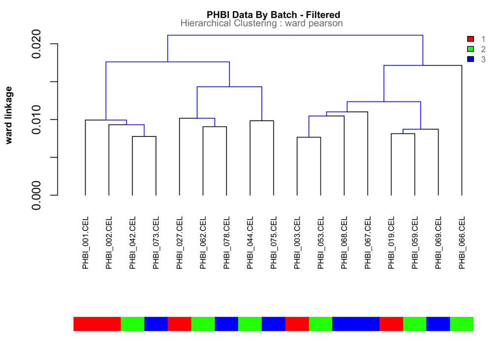

```r
clustering.plot(tree = PUBHI.sample2, lab = PBHI.batch.cl, title = "PHBI Data By Batch - Filtered")
```